# Exploration & Clustering of Crime in Louisville

Delores Mincarelli

2023-05-31

### Motivation

#### Clustering Approach

- I chose to cluster the data based on zip code and the type of crime, like Assault or Theft.
- Because each zip code has a different number of residents, I normalized the data by evaluating the percent of crime type rather than the number of each crime type.

#### Actionable Insights from Clustering

- Cluster #1, with a high percentage of sex crimes, is so different from the others it makes sense that it stands alone - that is the whole point of using clustering. The fact that it contains only one zipcode makes it a perfect candidate for focused intervention.  
  What additional services are needed in this zipcode from a social service and law enforcement standpoint?  
  What is the root cause of why is this happening to this extent in only this zipcode?
- Cluster #2 is characterized by ~21% Theft crimes, followed by ~18% Assault.
- Cluster #3 is characterized by ~26% Assault.  
  Because of the large number of zipcodes in each of these clusters, it is likely that the physical locations is varied around the city. Thus, a more generalized approach to tackling these crimes may be appropriate. In addition, we could re-cluster these zipcodes and drill down to more granular descriptions for Assault and Theft to see if there is a more nuanced approach that would make sense.

### Load Packages

```r
library(tidyverse)
library(lubridate)
library(DataExplorer)  # automatic EDA
library(tidyquant)     # theme_tq()
library(forcats)       # factors
library(broom)         # extract data from function object
library(umap)          # put clusters in 2-D map
library(ggrepel)       # labeling
```

### Import Louisville 2022 Crime Data

#### Download Data & Data Dictionary:

https://catalog.data.gov/dataset/louisville-metro-ky-crime-data-2022

```r
lville_crime_raw_tbl <- read.csv("data/crime/Louisville_Metro_KY_-_Crime_Data_2022.csv") %>%
                        as_tibble() %>%
                        set_names(names(.) %>% str_to_lower()) %>%
                        glimpse()
```

```
## Rows: 71,506
## Columns: 16
## $ ï..incident_number <chr> "80-22-000334", "80-22-000333", "80-22-000335", "80~
## $ date_reported      <chr> "2022/01/02 16:49:00", "2022/01/02 18:14:00", "2022~
## $ date_occured       <chr> "2022/01/02 15:49:00", "2022/01/02 18:00:00", "2022~
## $ badge_id           <chr> "5276            ", "5363            ", "8063      ~
## $ crime_type         <chr> "DRUGS/ALCOHOL VIOLATIONS", "BURGLARY", "THEFT/LARC~
## $ uor_desc           <chr> "POSS CONT SUB-1ST DEGREE-1ST OFFENSE-HEROIN", "BUR~
## $ nibrs_code         <chr> "35A", "220", "23H", "90Z", "23C", "290", "23G", "2~
## $ ucr_hierarchy      <chr> "PART II", "PART I", "PART I", "PART II", "PART I",~
## $ att_comp           <chr> "COMPLETED", "COMPLETED", "COMPLETED", "COMPLETED",~
## $ lmpd_division      <chr> "6TH DIVISION", "6TH DIVISION", "4TH DIVISION", "2N~
## $ lmpd_beat          <chr> "625", "624", "424", "223", "323", "724", "724", "7~
## $ premise_type       <chr> "RESTAURANT                                   ", "O~
## $ block_address      <chr> "3400 BLOCK BARDSTOWN RD                           ~
## $ city               <chr> "LOUISVILLE", "LOUISVILLE", "LOUISVILLE", "LOUISVIL~
## $ zip_code           <chr> "40218", "40218", "40214", "40211", "40214", "40229~
## $ objectid           <int> 1, 2, 3, 4, 5, 6, 7, 8, 9, 10, 11, 12, 13, 14, 15, ~
```

### Cleaning, Feature Engineering

#### I used the date and time that a crime occurred to add additional features like month, weekday, and hour.

```r
lville_crime_select_tbl <- lville_crime_raw_tbl %>%
    filter(city == "LOUISVILLE" & year(as_datetime(date_occured))== 2022 & nchar(zip_code)==5) %>%
    mutate(
          count_me      = 1,
          pm_vs_am_flag = as.numeric(pm(as_datetime(date_occured))),
          weekday_flag  = ifelse(weekdays(as_datetime(date_occured)) %in% c("Saturday", "Sunday"),0, 1),
          premise_type  = premise_type %>% str_trim(),
          hour_of_day   = hour(as_datetime(date_occured)),
          month_of_year = as_factor(month(as_datetime(date_occured), label = TRUE )),
          day_of_week   = as_factor(wday(as_datetime(date_occured),  label = TRUE )),
          day_of_month  = day(as_datetime(date_occured))
          ) %>%
    select(
          count_me
        , date_occured
        , zip_code
        , weekday_flag
        , hour_of_day
        , month_of_year
        , day_of_week
        , day_of_month
        , pm_vs_am_flag
        , crime_type
        , uor_desc
        , premise_type
    ) %>%
    glimpse()
```

```
## Rows: 69,305
## Columns: 12
## $ count_me      <dbl> 1, 1, 1, 1, 1, 1, 1, 1, 1, 1, 1, 1, 1, 1, 1, 1, 1, 1, 1,~
## $ date_occured  <chr> "2022/01/02 15:49:00", "2022/01/02 18:00:00", "2022/01/0~
## $ zip_code      <chr> "40218", "40218", "40214", "40211", "40214", "40229", "4~
## $ weekday_flag  <dbl> 0, 0, 0, 0, 0, 0, 0, 0, 0, 0, 0, 0, 0, 0, 0, 0, 0, 0, 0,~
## $ hour_of_day   <int> 15, 18, 21, 18, 18, 19, 19, 14, 15, 19, 19, 19, 19, 18, ~
## $ month_of_year <ord> Jan, Jan, Jan, Jan, Jan, Jan, Jan, Jan, Jan, Jan, Jan, J~
## $ day_of_week   <ord> Sun, Sun, Sat, Sun, Sun, Sat, Sat, Sun, Sun, Sun, Sun, S~
## $ day_of_month  <int> 2, 2, 1, 2, 2, 1, 1, 2, 2, 2, 2, 2, 2, 2, 1, 2, 2, 2, 2,~
## $ pm_vs_am_flag <dbl> 1, 1, 1, 1, 1, 1, 1, 1, 1, 1, 1, 1, 1, 1, 1, 1, 1, 1, 1,~
## $ crime_type    <chr> "DRUGS/ALCOHOL VIOLATIONS", "BURGLARY", "THEFT/LARCENY",~
## $ uor_desc      <chr> "POSS CONT SUB-1ST DEGREE-1ST OFFENSE-HEROIN", "BURGLARY~
## $ premise_type  <chr> "RESTAURANT", "OTHER RESIDENCE (APARTMENT/CONDO)", "HIGH~
```

### Identify and remove zipcodes with less than 10 crimes

#### The data for these zips is likely incomplete.

```r
remove_zips <- lville_crime_select_tbl %>%
                select( count_me
                        , zip_code) %>%
                group_by(zip_code) %>%
                summarize(count_of_crimes = sum(count_me)) %>%
                filter(count_of_crimes < 10) %>%
                distinct(zip_code) %>%
                pull()

lville_crime_select_tbl <- lville_crime_select_tbl %>%
                            filter(!(zip_code %in% remove_zips))
```

### Exploratory Data Analysis - I created 3 functions for visualizing data

### (1) Function for bar charts

```r
# The enquo() function is short for "enquoting,"
# By using enquo(), we can capture the column name provided as an argument in the function call and use it later within the dplyr pipeline without immediately evaluating it.
# The quo_name() function is used to extract the name of a quosure object. It takes a quosure as an argument and returns the name of the expression as a character string.
# Together, enquo() and quo_name() allow us to capture and manipulate unevaluated expressions
# They are part of tidyverse

bar_plot_function <- function(df, group_col, n = NULL) {
  group_col <- enquo(group_col)  # Capture the column name as a quosure

  df %>%
    select(count_me, !!group_col) %>%
    group_by(!!group_col) %>%
    summarise(count_crimes = sum(count_me)) %>%
    mutate(col_group = !!group_col %>% as_factor() %>% fct_reorder(count_crimes)) %>%
    filter(if (!is.null(n)) rank(desc(count_crimes), ties.method = "min") <= n else TRUE) %>%
    ggplot(aes(x = col_group, y = count_crimes, fill = "#2c3e50")) +
    geom_col() +
    coord_flip() +
    theme_tq() +
    theme(panel.grid.major.y = element_blank(),  # Remove horizontal gridlines
          panel.grid.minor = element_blank()) +
    labs(title = paste0("Crimes in 2022 by ", quo_name(group_col)),
         subtitle = if (!is.null(n)) paste0("Showing the top ", n)) +
    xlab(NULL) +
    ylab("Count of Crimes") +
    scale_fill_identity()
}
```

### (2) Function for line charts

```r
line_plot_function <- function(df, group_col, n = NULL, xlabel = NULL, sub_title = NULL) {
  group_col <- enquo(group_col)  # Capture the column name as a quosure


  df %>%
    select(count_me, !!group_col) %>%
    group_by(!!group_col) %>%
    summarise(count_crimes = sum(count_me)) %>%
    ggplot(aes(x = !!group_col, y = count_crimes )) +
    geom_line(linewidth = 2, linetype = 1, color = "#2c3e50") +
    theme_tq() +
    theme(panel.grid.major.y = element_blank(),  # Remove horizontal gridlines
          panel.grid.minor = element_blank()) +
    labs(title = paste0("Crimes in 2022 by ", quo_name(group_col)),
         subtitle = sub_title ) +
    xlab(xlabel) +
    ylab("Count of Crimes") +
    scale_fill_identity()
}
```

### (3) Function for column chart

```r
col_plot_function <- function(df, group_col,  xlabel = NULL, sub_title = NULL) {
  group_col <- enquo(group_col)  # Capture the column name as a quosure


  df %>%
    select(count_me, !!group_col) %>%
    group_by(!!group_col) %>%
    summarise(count_crimes = sum(count_me)) %>%
    ggplot() +
    geom_col(aes(x = !!group_col, y = count_crimes ), fill = "#2c3e50") +
    theme_tq() +
    theme(panel.grid.major.y = element_blank(),  # Remove horizontal gridlines
          panel.grid.minor = element_blank()) +
    labs(title = paste0("Crimes in 2022 by ", quo_name(group_col)),
         subtitle = sub_title ) +
    xlab(xlabel) +
    ylab("Count of Crimes")

}
```

### Crimes by Hour of Day

##### Interesting that midnight and noon have the highest crime volume.

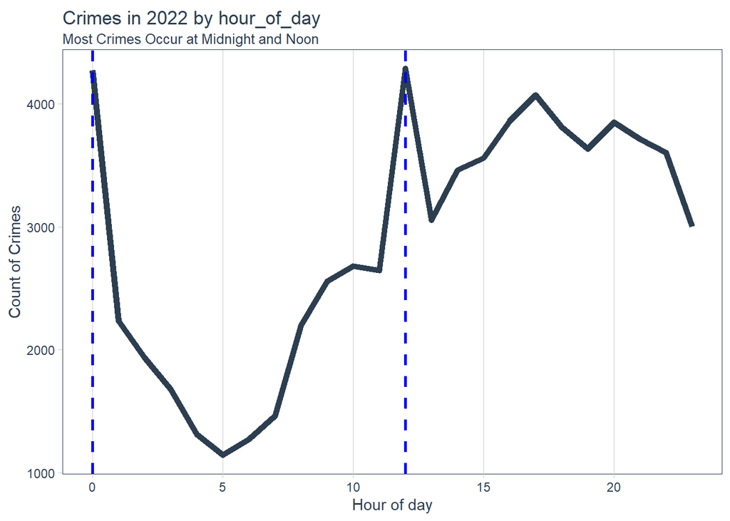

```r
hour_plot <- line_plot_function(lville_crime_select_tbl, group_col = hour_of_day, xlabel = "Hour of day", sub_title = "Most Crimes Occur at Midnight and Noon")

# Add vertical lines
line_x1 <- 0  # x-coordinate of the first vertical line
line_x2 <- 12  # x-coordinate of the second vertical line

hour_plot <- hour_plot +
  geom_vline(xintercept = line_x1, linetype = "dashed", color = "blue", linewidth = 1) +
  geom_vline(xintercept = line_x2, linetype = "dashed", color = "blue", linewidth = 1)

# Step 5: Display the plot
print(hour_plot)
```

### Crimes by Day of Week

#### Day of Week crime volume is remarkably similar - we don’t learn much from this variable.

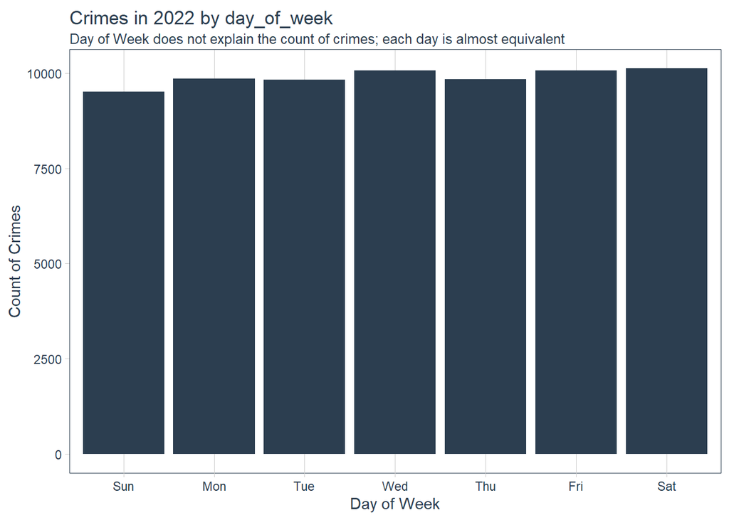

```r
col_plot_function(lville_crime_select_tbl, group_col = day_of_week, xlabel = "Day of Week", sub_title = "Day of Week does not explain the count of crimes; each day is almost equivalent")
```

### Crimes by Month

#### Summer months have the highest crime with the month of May following close behind.

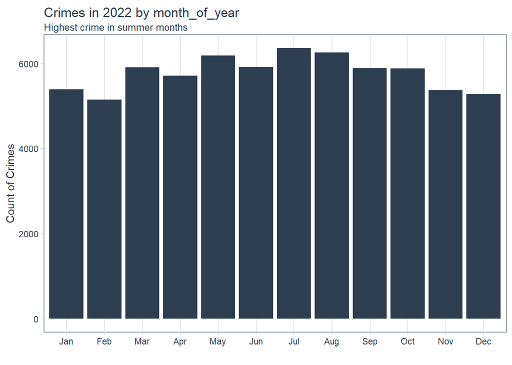

```r
col_plot_function(lville_crime_select_tbl, group_col = month_of_year, xlabel = "", sub_title = "Highest crime in summer months")
```

### What was the impact of the Kentucky Derby on crime in May?

#### Horse races started Wed May 4 and ended with the Kentucky Derby race on May 7

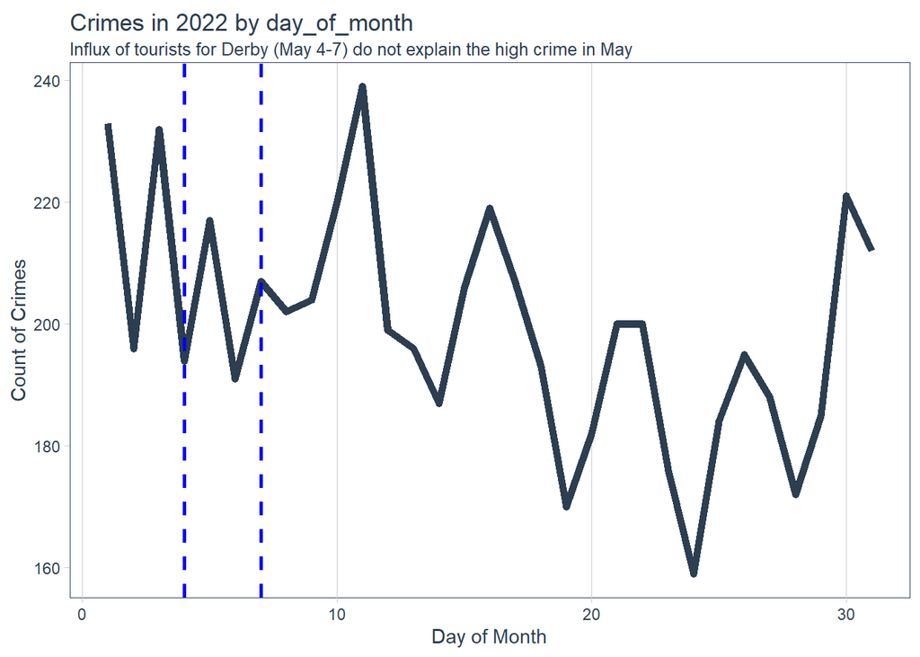

```r
month_may_tbl <- lville_crime_select_tbl %>%
    filter(month_of_year == "May" )

derby_plot <- line_plot_function(month_may_tbl, group_col = day_of_month, xlabel = "Day of Month", sub_title = "Influx of tourists for Derby (May 4-7) do not explain the high crime in May")

# Add vertical lines
line_x1 <- 4  # x-coordinate of the first vertical line
line_x2 <- 7  # x-coordinate of the second vertical line

derby_plot <- derby_plot +
  geom_vline(xintercept = line_x1, linetype = "dashed", color = "blue", linewidth = 1) +
  geom_vline(xintercept = line_x2, linetype = "dashed", color = "blue", linewidth = 1)

# Step 5: Display the plot
print(derby_plot)
```

### Count of Crimes by Zip code

#### Not surprising that some zips have more crimes than others. I will also look at crime type to see if there is stratification among zipcodes.

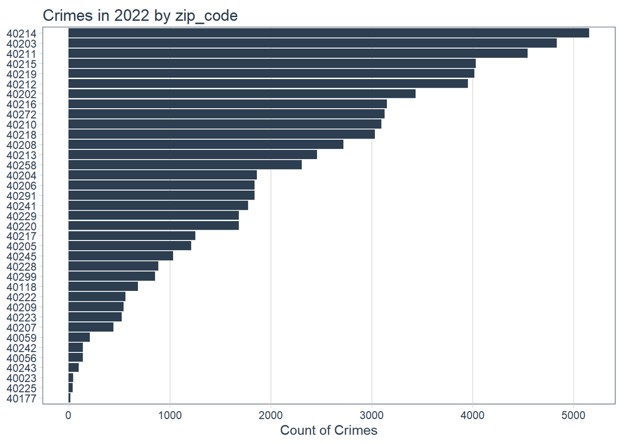

```r
bar_plot_function(lville_crime_select_tbl, group_col = zip_code)
```

### Count of Crimes in Morning (am) vs Afternoon/Evening

#### More crimes occur in the afternoon / evening than morning

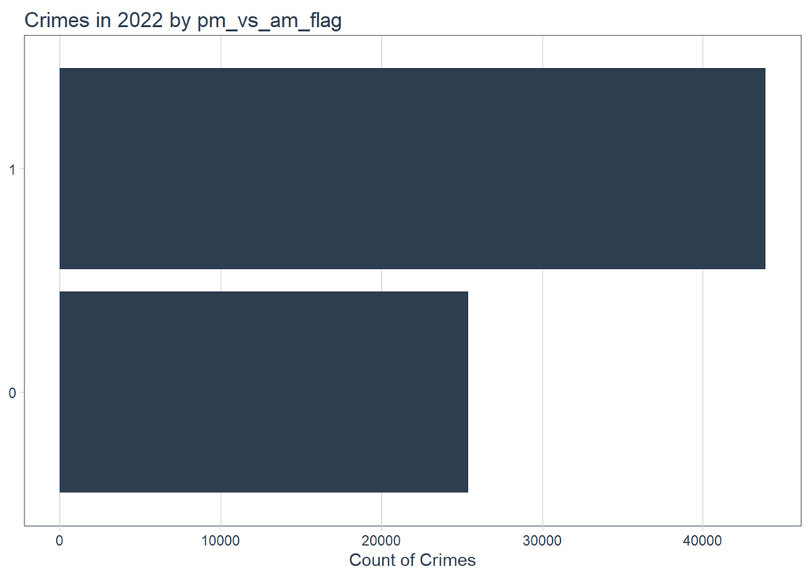

```r
bar_plot_function(lville_crime_select_tbl, group_col = pm_vs_am_flag)
```

### Count of Crimes by Type

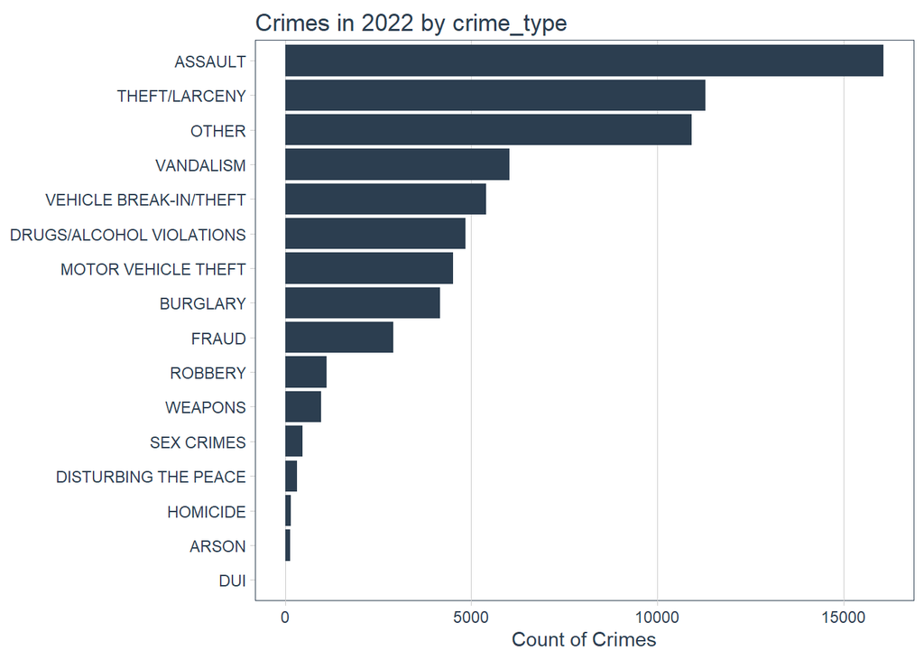

```r
bar_plot_function(lville_crime_select_tbl, group_col = crime_type)
```

### Break down crime type “Assault” into more detail, using “uor_desc” data element

#### uor_desc - Uniform Offense Reporting code for the criminal act committed

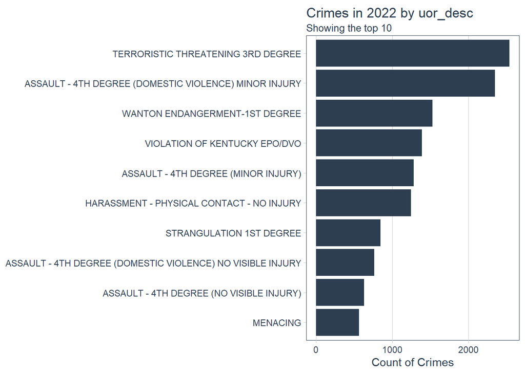

```r
assault_tbl <- lville_crime_select_tbl %>%
    filter(crime_type == "ASSAULT")

bar_plot_function(assault_tbl, group_col = uor_desc, n = 10)
```

### Break down crime type “Other” into more detail

#### “Other” is predominantly Domestic Abuse Duties and Missing Persons

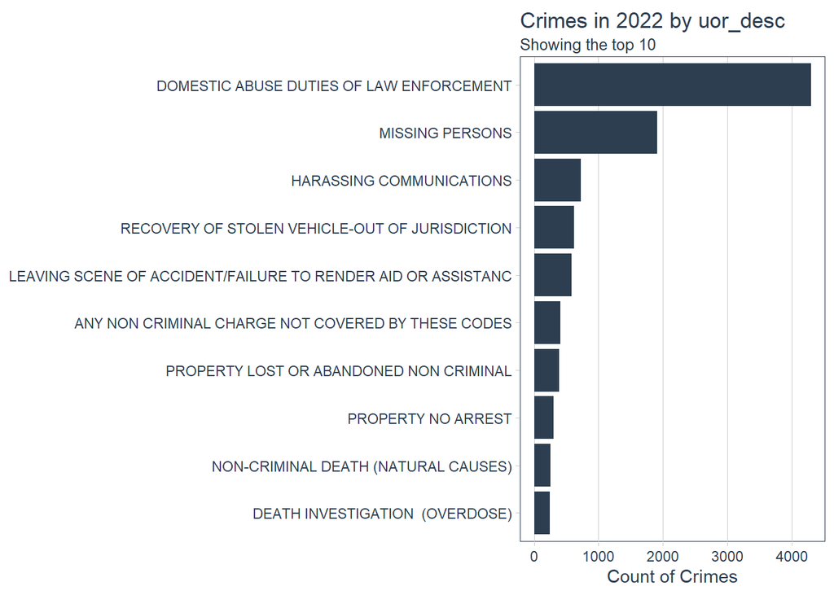

```r
Other_tbl <- lville_crime_select_tbl %>%
    filter(crime_type == "OTHER")

bar_plot_function(Other_tbl, group_col = uor_desc, n = 10)
```

### Most Crimes occur in Residence/Home vs Outside or Commercial buildings

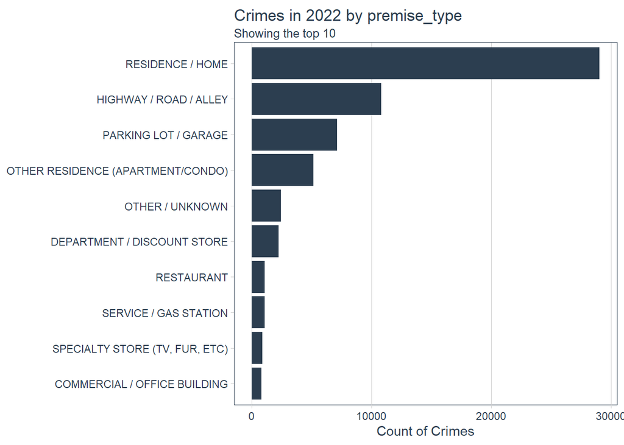

```r
bar_plot_function(lville_crime_select_tbl, group_col = premise_type, n = 10)
```

### Prepare Data for clustering, focusing on zip and crime type

### We will normalize the data by getting the proportion of each type by zip

##### K-means clustering is a popular unsupervised machine learning algorithm used for partitioning a dataset into a predefined number of clusters. The goal of k-means clustering is to group similar data points together and minimize the intra-cluster variance.

##### The algorithm works by iteratively assigning data points to the nearest cluster centroid and updating the centroids based on the newly assigned points.

```r
lville_crime_grouped_tbl <- lville_crime_select_tbl %>%
    select( count_me
           ,zip_code
           ,crime_type) %>%
    group_by(zip_code, crime_type)%>%
    summarize(sum_crimes = sum(count_me)) %>%
    ungroup() %>%

    # Proportion
    group_by(zip_code) %>%
    mutate(prop_of_total = sum_crimes / sum(sum_crimes)) %>%
    ungroup()

    head(lville_crime_grouped_tbl)
```

```
## # A tibble: 6 x 4
##   zip_code crime_type          sum_crimes prop_of_total
##   <chr>    <chr>                    <dbl>         <dbl>
## 1 40023    ASSAULT                     16        0.372
## 2 40023    BURGLARY                     5        0.116
## 3 40023    FRAUD                        2        0.0465
## 4 40023    MOTOR VEHICLE THEFT          2        0.0465
## 5 40023    OTHER                        9        0.209
## 6 40023    THEFT/LARCENY                7        0.163
```

### Pivot Data so crime types become columns

#### Remove zip_code label column to prepare matrix for K-Means

#### K-Means must have numerical data only

```r
zip_crime_tbl <- lville_crime_grouped_tbl %>%
    select(zip_code, crime_type, prop_of_total) %>%
    pivot_wider(names_from = crime_type, values_from = prop_of_total, values_fill = 0)

zip_crime_mtx <- zip_crime_tbl %>%
                     select(-zip_code)

print(zip_crime_mtx)
```

```
## # A tibble: 37 x 16
##    ASSAULT BURGLARY  FRAUD `MOTOR VEHICLE THEFT` OTHER `THEFT/LARCENY`
##      <dbl>    <dbl>  <dbl>                 <dbl> <dbl>           <dbl>
##  1   0.372   0.116  0.0465                0.0465 0.209          0.163
##  2   0.177   0      0.0426                0      0.383          0.0142
##  3   0.206   0.0766 0.0622                0.0766 0.124          0.177
##  4   0.262   0.0626 0.0597                0.0713 0.157          0.144
##  5   0.278   0      0                     0.111  0.222          0.222
##  6   0.240   0.0393 0.0262                0.0530 0.189          0.172
##  7   0.286   0.0618 0.0285                0.0507 0.161          0.115
##  8   0.174   0.0697 0.0348                0.0815 0.110          0.170
##  9   0.152   0.0545 0.0685                0.0726 0.112          0.213
## 10   0.167   0.0597 0.0451                0.0733 0.162          0.175
## # i 27 more rows
## # i 10 more variables: `VEHICLE BREAK-IN/THEFT` <dbl>,
## #   `DISTURBING THE PEACE` <dbl>, HOMICIDE <dbl>, `SEX CRIMES` <dbl>,
## #   VANDALISM <dbl>, ARSON <dbl>, `DRUGS/ALCOHOL VIOLATIONS` <dbl>,
## #   ROBBERY <dbl>, WEAPONS <dbl>, DUI <dbl>
```

### Create k-means function, using nstart = 100 and default of 3 clusters

#### We will vary the number of clusters and choose the best number once we evaluate the within-cluster-sum-squares.

```r
kmeans_mapper <- function(centers = 3) {
    set.seed(42)
    zip_crime_mtx %>%
        kmeans(centers = centers, nstart = 100)
}
```

### Prep for Skree Plot

#### Run K-Means for different cluster counts so we can evaluate within-cluster-sum-of-squares

#### This will inform our decision on the number of clusters to use

```r
# Here, we are creating tibble with one column called "centers", and providing 15 values
# which will be provided to kmeans_mapper function
# glance() pulls data elements from the k_means object, like "centers" and "tot.withinss"

kmeans_mapped_tbl <- tibble(centers = 1:15) %>%
mutate(k_means = centers %>% map(kmeans_mapper)) %>%
mutate(glance  = k_means %>% map(glance))


kmeans_mapped_tbl %>%
    unnest(glance) %>%
    select(centers, tot.withinss)
```

```
## # A tibble: 15 x 2
##    centers tot.withinss
##      <int>        <dbl>
##  1       1       0.754
##  2       2       0.525
##  3       3       0.353
##  4       4       0.274
##  5       5       0.224
##  6       6       0.180
##  7       7       0.150
##  8       8       0.121
##  9       9       0.0978
## 10      10       0.0816
## 11      11       0.0675
## 12      12       0.0572
## 13      13       0.0496
## 14      14       0.0428
## 15      15       0.0387
```

### Skree Plot

#### Plot cluster number and within sum-of-squares, to help choose number of clusters

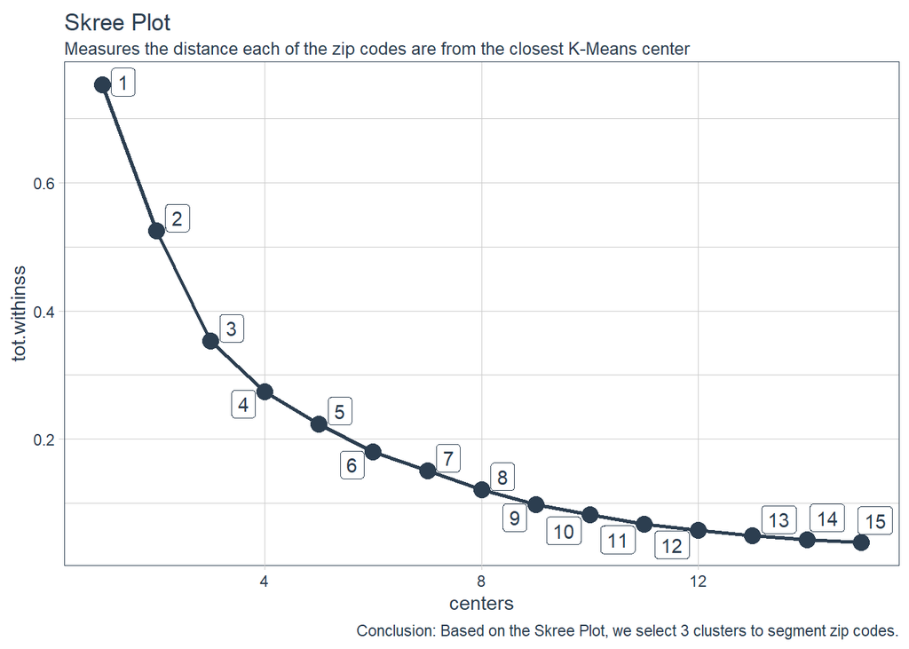

```r
kmeans_mapped_tbl %>%
    unnest(glance) %>%
    select(centers, tot.withinss) %>%

    # Visualization
    ggplot(aes(centers, tot.withinss)) +
    geom_point(color = "#2c3e50", size = 4) +
    geom_line(color = "#2c3e50", linewidth = 1) +
    ggrepel::geom_label_repel(aes(label = centers), color = "#2c3e50") +

    # Formatting
    theme_tq() +
    labs(
        title = "Skree Plot",
        subtitle = "Measures the distance each of the zip codes are from the closest K-Means center",
        caption = "Conclusion: Based on the Skree Plot, we select 3 clusters to segment zip codes."
    )
```

### Use 3 clusters and prepare to use umap() to visualize results

#### 3 clusters is when the within-cluster-sum-squares begins to flatten; this is a subjective cutoff. There is no right answer.

#### umap() is a dimensionality reduction technique commonly used for visualizing high-dimensional data in two dimensions

```r
umap_obj <- zip_crime_mtx %>%
    umap()

umap_results_tbl <- umap_obj$layout %>%
    as_tibble() %>%
    set_names(c("x", "y")) %>%
    bind_cols(
        zip_crime_tbl %>% select(zip_code)
    )


# # ---------------------------------------------------------
# #Use K-Means to Add Cluster Assignments ----
# # ---------------------------------------------------------

# # from kmeans_mapped_tbl, which has 1 to 15 centers and the kmeans object, we want to use
# # 3 clusters, so pull the k_means col, and pluck the 3rd row from the tibble for 3 clusters
# # result is the  kmeans object

kmeans_3_obj <- kmeans_mapped_tbl %>%
    pull(k_means) %>%
    pluck(3)

# add orig dataset to it to get zip code
kmeans_3_clusters_tbl <- kmeans_3_obj %>%
    augment(zip_crime_tbl) %>%
    select(zip_code, .cluster)

# join to umap on zip
umap_kmeans_3_results_tbl <- umap_results_tbl %>%
    left_join(kmeans_3_clusters_tbl)
```

### Define Each Cluster - what are the characteristics that differentiate each cluster?

#### Join the cluster assignment from K-Means back to original dataset so we can get more context for the clusters.

```r
zip_crime_cluster_tbl <- lville_crime_select_tbl %>%
    select( zip_code
           ,crime_type
           ,count_me) %>%
    left_join(kmeans_3_clusters_tbl) %>%
    group_by(.cluster, crime_type) %>%
    summarize(count_me = sum(count_me)) %>%
    ungroup() %>%
    # Calculate Proportion of Total
    group_by(.cluster) %>%
    mutate(prop_of_total = count_me /sum(count_me)) %>%
    mutate(prop_of_total = round(prop_of_total,3)*100.00) %>%
    ungroup()
```

### Explore Cluster 1 - top 3 crime types

#### This cluster is unusual - there is only one zipcode, which is defined by “Other” & “Sex Crimes” in very high proportion compared to other zipcodes.

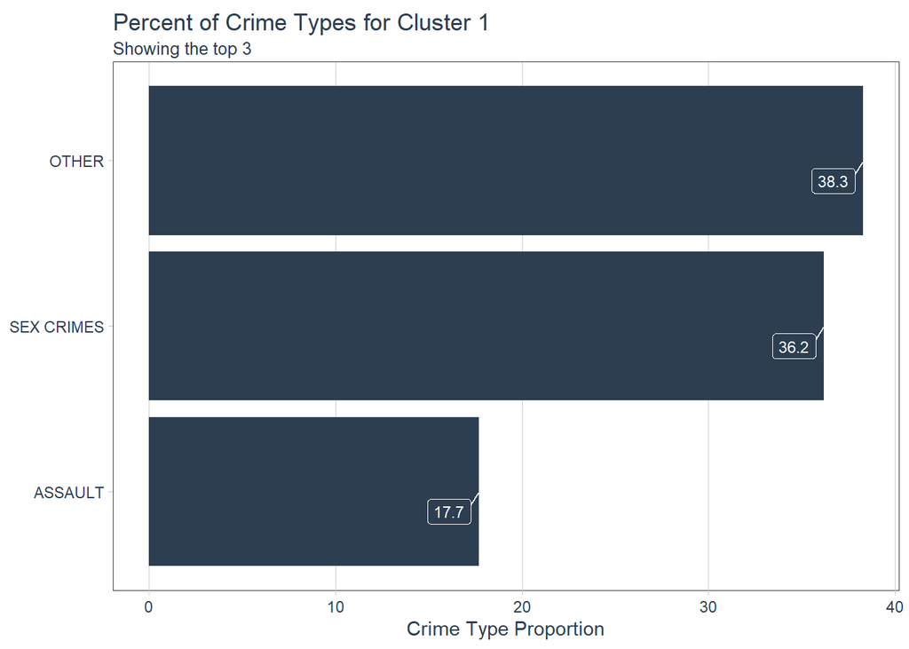

```r
zip_crime_cluster_1 <- zip_crime_cluster_tbl %>%
    filter(.cluster == 1) %>%
    arrange(desc(prop_of_total))

cluster_number <- zip_crime_cluster_1 %>% distinct(.cluster) %>%  pull()
chart_title <- paste0("Percent of Crime Types for Cluster ", cluster_number)

bar_proportion_function(zip_crime_cluster_1, group_col = crime_type, title=chart_title,  n = 3)
```

### Explore Cluster 2 - top 3 crime types

#### Over 50% of the crimes in this cluster are desribed by Theft, Assault, and Other.

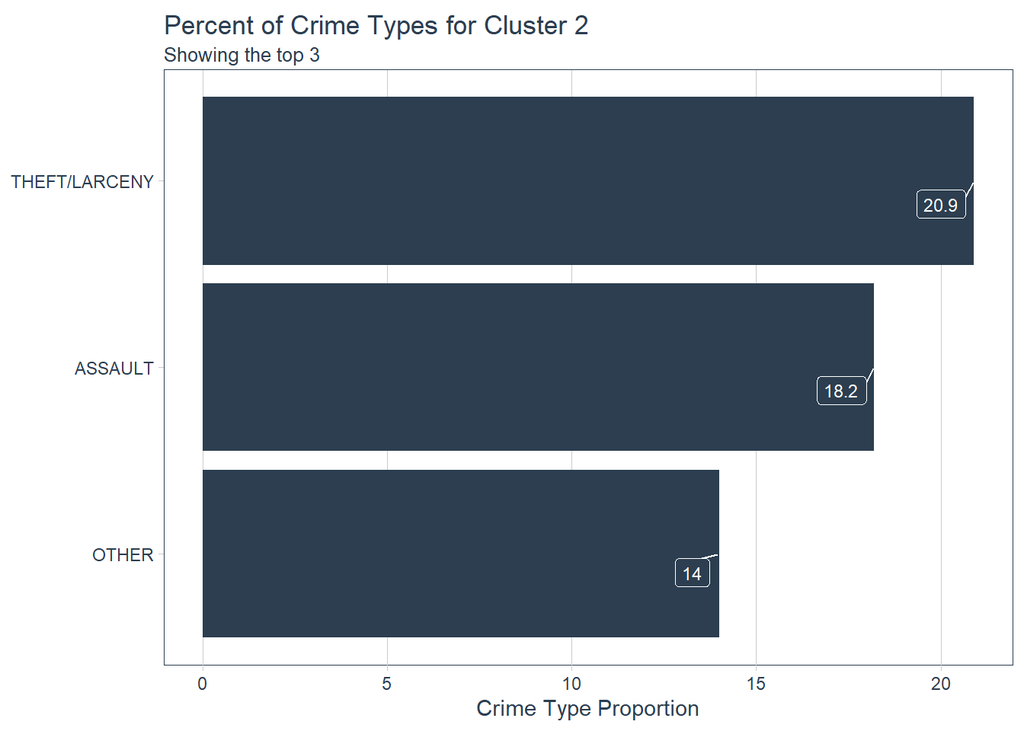

```r
zip_crime_cluster_2 <- zip_crime_cluster_tbl %>%
    filter(.cluster == 2) %>%
    arrange(desc(prop_of_total))

cluster_number <- zip_crime_cluster_2 %>% distinct(.cluster) %>%  pull()
chart_title <- paste0("Percent of Crime Types for Cluster ", cluster_number)

bar_proportion_function(zip_crime_cluster_2, group_col = crime_type, title=chart_title,  n = 3)
```

### Explore Cluster 3 - top 3 crime types

#### This cluster had zipcodes with the highest percentage of Assault.

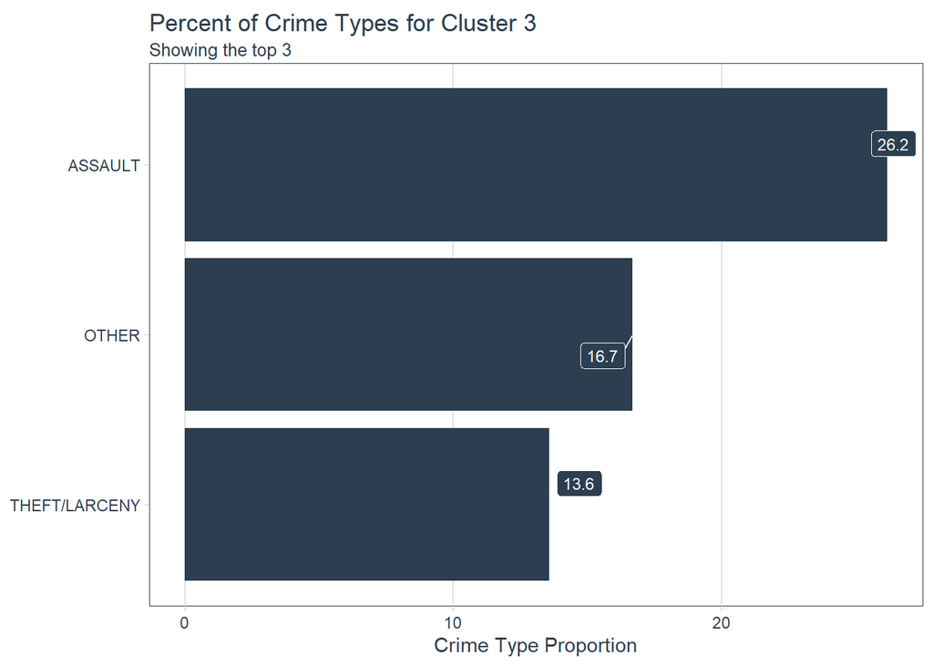

```r
zip_crime_cluster_3 <- zip_crime_cluster_tbl %>%
    filter(.cluster == 3) %>%
    arrange(desc(prop_of_total))

cluster_number <- zip_crime_cluster_3 %>% distinct(.cluster) %>%  pull()
chart_title <- paste0("Percent of Crime Types for Cluster ", cluster_number)

bar_proportion_function(zip_crime_cluster_3, group_col = crime_type, title=chart_title,  n = 3)
```

### Visualize Clusters with their Descriptions

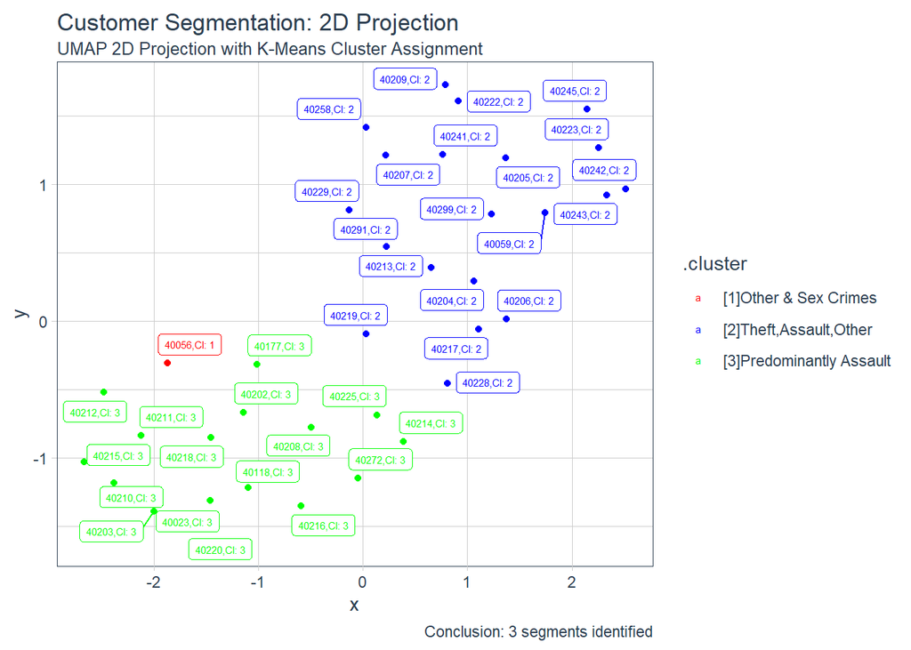

```r
cluster_label_tbl <- tibble(
    .cluster = 1:3,
    .cluster_label = c(
        "Other & Sex Crimes",
        "Mix of Theft, Assault, Other",
        "Highest Percentage of Assault"
    )
) %>%
    mutate(.cluster = as_factor(as.character(.cluster)))

# Add to the plot
cluster_label_loc <- umap_kmeans_3_results_tbl |>
    group_by(.cluster) |>
    summarize(x = min(x) - 0.1, y = max(y) - 0.1) |>
    left_join(cluster_label_tbl)

# Then add to the plot:
    umap_kmeans_3_results_tbl |>
    mutate(label_text = str_glue("{zip_code},Cl: {.cluster}")) %>%
    ggplot(aes(x, y, color = .cluster)) +
    geom_point() +
    geom_label_repel(aes(label = label_text), size = 2) +
    theme_tq() +
    scale_color_tq() +
    labs(
        title = "Customer Segmentation: 2D Projection",
        subtitle = "UMAP 2D Projection with K-Means Cluster Assignment",
        caption = "Conclusion: 3 segments identified"
    ) +
    scale_color_manual(values = c("1" = "red", "2" = "blue", "3" = "green"),
                       labels = c("1" = "[1]Other & Sex Crimes", "2" = "[2]Theft,Assault,Other",
                                "3" = "[3]Predominantly Assault")) +
    theme(legend.position = "right")
```